# match data

#### i) Match won by the maximum margin of runs.

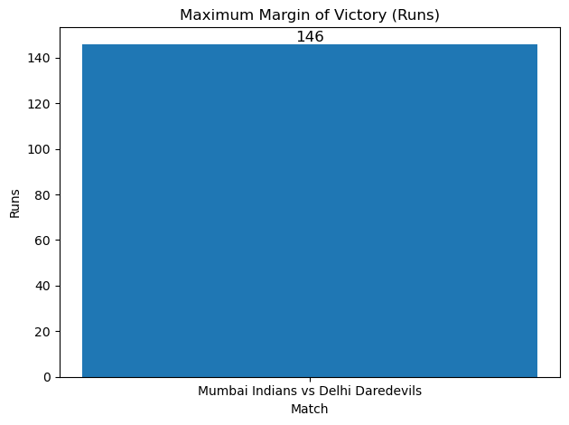

```python
import pandas as pd
import matplotlib.pyplot as plt

df = pd.read_csv("matches.csv")

max_margin = df['win_by_runs'].max()

max_match = df[df['win_by_runs'] == max_margin].iloc[0]

winner = max_match['winner']
team1 = max_match['team1']
team2 = max_match['team2']

opponent = team2 if winner == team1 else team1

label = f"{winner} vs {opponent}"

plt.figure()
bars = plt.bar(label, max_margin)

plt.xlabel("Match",)
plt.ylabel("Runs")
plt.title("Maximum Margin of Victory (Runs)")

plt.text(label, max_margin, str(max_margin),
         ha='center', va='bottom', fontsize=12)

plt.xticks(rotation=0)
plt.tight_layout()

plt.show()
```

#### insights

-Highest Winning Margin: -The maximum victory margin shown is 146 runs.

-Teams Involved: -The match was between Mumbai Indians and Delhi Daredevils.

-Dominant Performance: -A 146-run win is a very large margin in T20 cricket, indicating:

-Extremely strong batting performance by the winning team.

-Weak batting performance (or collapse) by the losing team.

-Rare Event: -Such a huge run-margin win is uncommon in IPL history, making this match statistically significant.

-Strategic Impact:

-High margin victories improve Net Run Rate (NRR) significantly.

-Such wins can help teams qualify for playoffs in close seasons.

#### ii) Match won by maximum wickets.

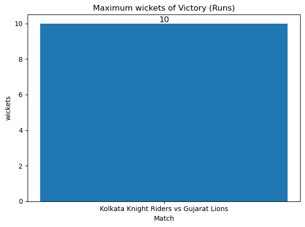

```python
import pandas as pd
import matplotlib.pyplot as plt

df = pd.read_csv("matches.csv")

max_wickets = df['win_by_wickets'].max()

max_match = df[df['win_by_wickets'] == max_wickets].iloc[0]

winner = max_match['winner']
team1 = max_match['team1']
team2 = max_match['team2']

opponent = team2 if winner == team1 else team1

label = f"{winner} vs {opponent}"

plt.figure()
plt.bar(label, max_wickets)

plt.xlabel("Match")
plt.ylabel("wickets")
plt.title("Maximum wickets of Victory (Runs)")

plt.text(label, max_wickets, str(max_wickets),
         ha='center', va='bottom', fontsize=12)

plt.xticks(rotation=0)
plt.tight_layout()

plt.show()
```

#### Insights

-Maximum Wicket Margin: -The highest wicket victory shown is 10 wickets.

-Teams Involved: -The match was between Kolkata Knight Riders and Gujarat Lions.

-Complete Dominance: -A 10-wicket win means:

-The chasing team achieved the target without losing any wickets.

-This indicates a very strong opening partnership.

-The bowling team failed to take even one wicket.

#### iii) Match won by the minimum margin of runs.

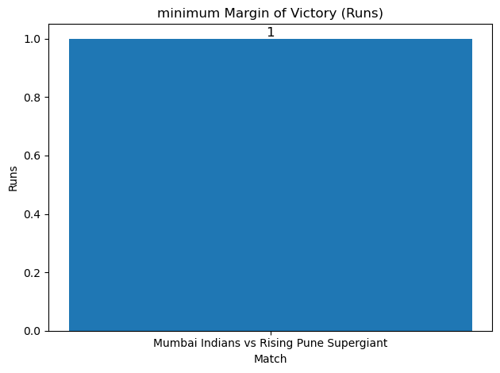

```python
import pandas as pd
import matplotlib.pyplot as plt

df = pd.read_csv("matches.csv")

run_wins = df[df['win_by_runs'] > 0]

min_margin = run_wins['win_by_runs'].min()

min_match = run_wins[run_wins['win_by_runs'] == min_margin].iloc[0]

winner = min_match['winner']
team1 = min_match['team1']
team2 = min_match['team2']

opponent = team2 if winner == team1 else team1

label = f"{winner} vs {opponent}"

plt.figure()
bars = plt.bar(label, min_margin)

plt.xlabel("Match")
plt.ylabel("Runs")
plt.title("minimum Margin of Victory (Runs)")

plt.text(label, min_margin, str(min_margin),
         ha='center', va='bottom', fontsize=12)

plt.xticks(rotation=0)
plt.tight_layout()

plt.show()
```